# Summary Plots and Statistics for HICEAS 2017 Odontocete Events

##### Whistle plots and table

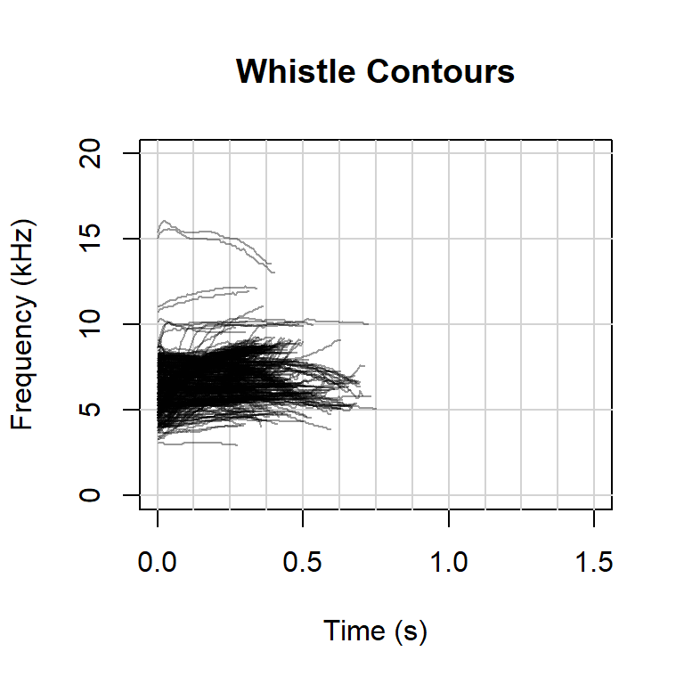

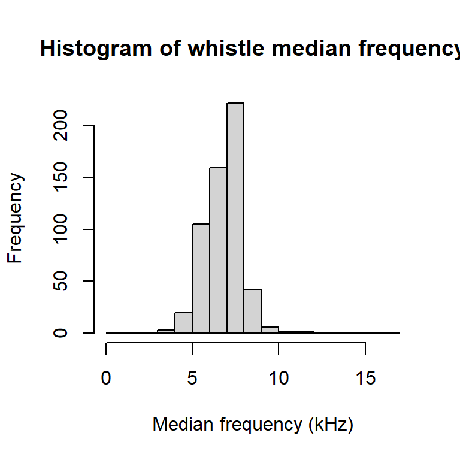

Median statistics for n = 562 whistles.

| parameter | value |
| --- | --- |
| Median begin frequency [kHz] | 6.08 |
| Median end frequency [kHz] | 6.88 |
| Median mean frequency [kHz] (SD) | 6.87 (0.36) |
| Median duration [s] | 0.362 |
| Median frequency range [kHz] (min-max) | 1.32 (5.64 - 7.76) |

#### Event ID: 1705110 | Species: 36

Time: 2017-09-12 18:15UTC to 2017-09-12 18:18UTC

Event contains 601 original clicks, **2 valid clicks** after filtering.

Event contains **10 whistles**.

##### Click plots and table

SNR histogram includes all filtered clicks. Other plots contain only clicks with SNR >= 15 dB (**n = 2 clicks**) .

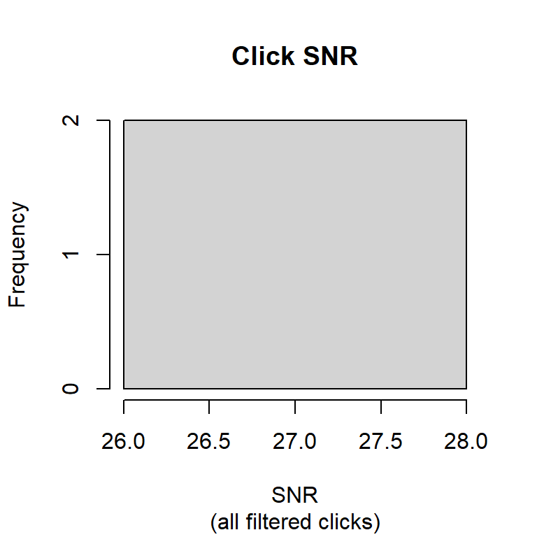

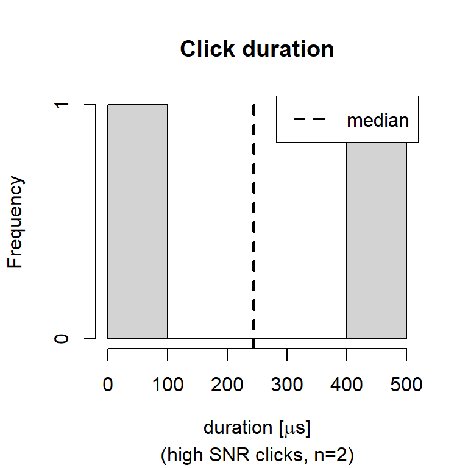

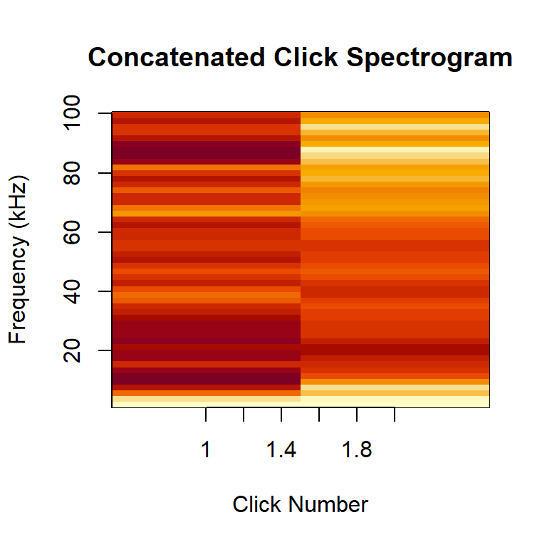

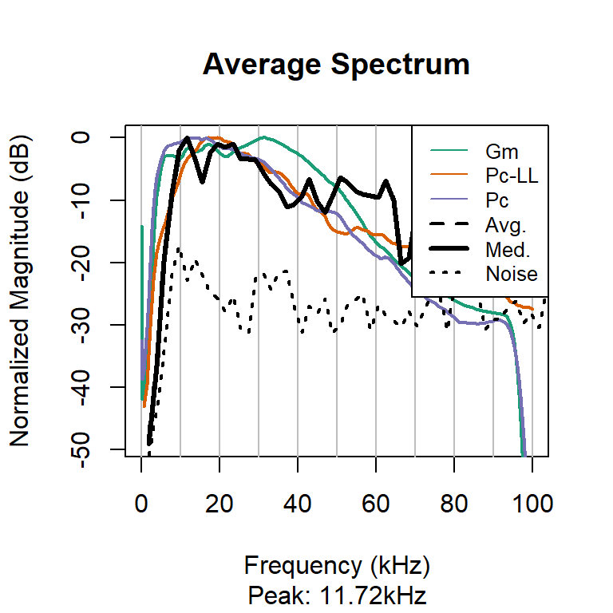

Median statistics for 2 high SNR clicks with SNR >= 15 dB.

| parameter | value |
| --- | --- |
| Median Peak Frequency [kHz] | 14.2 |
| Median 3dB Center Frequency [kHz] | 19.5 |
| Median 10dB Center Frequency [kHz] | 20.1 |
| Median 3dB Bandwidth [kHz] (lower-upper) | 1.36 (18.8 - 20.2) |
| Median 10dB Bandwidth [kHz] (lower-upper) | 5.66 (17.3 - 22.9) |
| Median duration [μs] (25-75 percentile) | 244 (123 - 365) |

##### Whistle plots and table

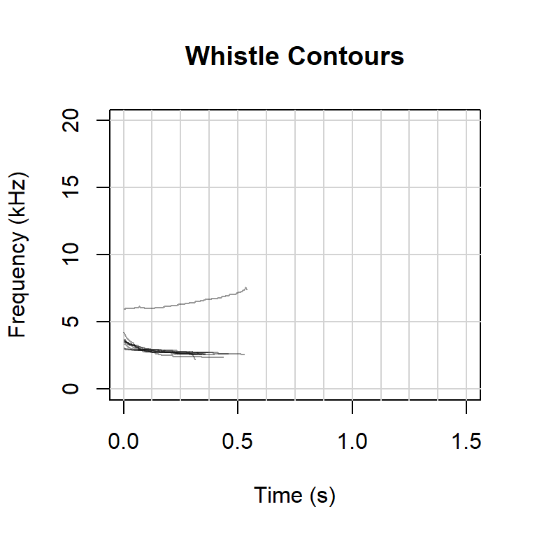

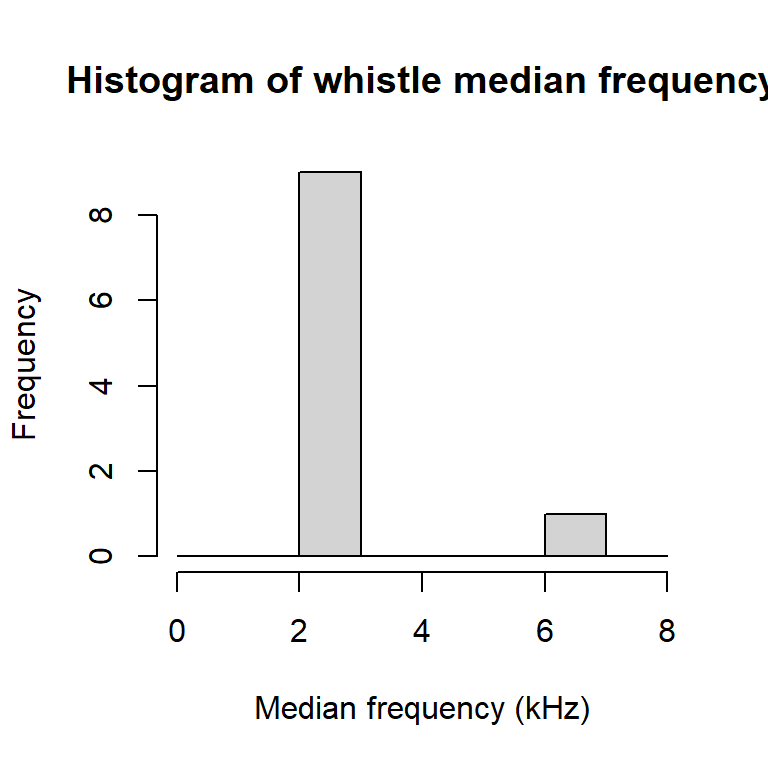

Median statistics for n = 10 whistles.

| parameter | value |
| --- | --- |
| Median begin frequency [kHz] | 3.55 |
| Median end frequency [kHz] | 2.56 |
| Median mean frequency [kHz] (SD) | 2.84 (0.24) |
| Median duration [s] | 0.389 |
| Median frequency range [kHz] (min-max) | 0.92 (2.56 - 3.55) |

#### Event ID: 1705114 | Species: 36

Time: 2017-09-13 01:23UTC to 2017-09-13 02:27UTC

Event contains 66133 original clicks, **4029 valid clicks** after filtering.

Event contains **843 whistles**.

##### Click plots and table

SNR histogram includes all filtered clicks. Other plots contain only clicks with SNR >= 15 dB (**n = 3854 clicks**) .

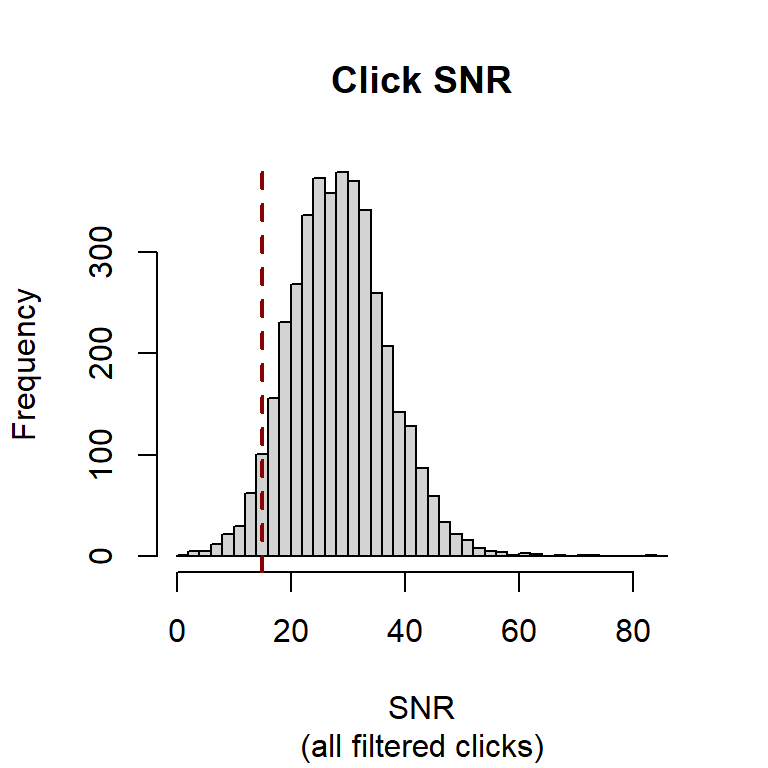

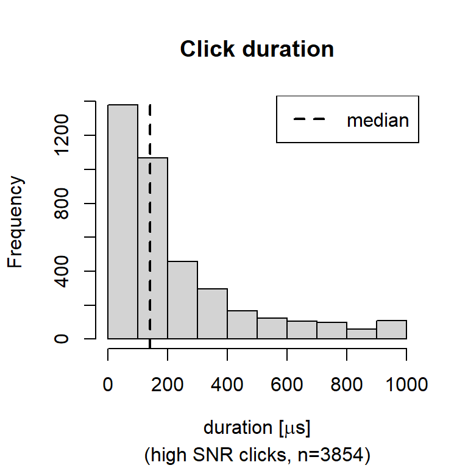

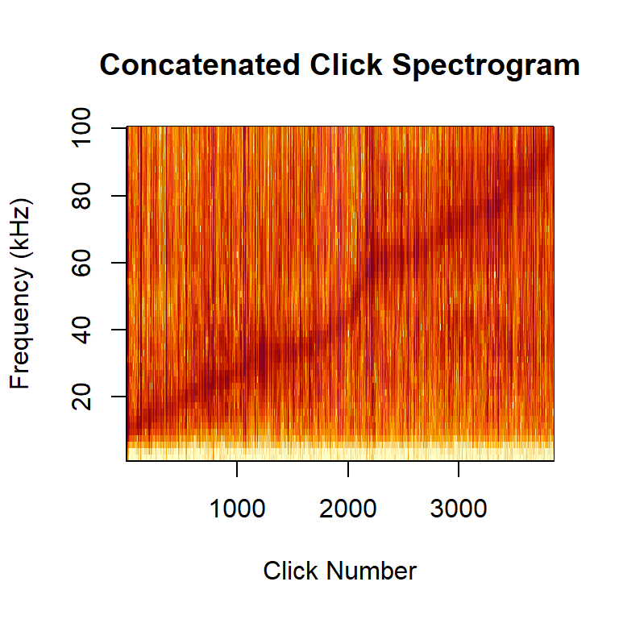

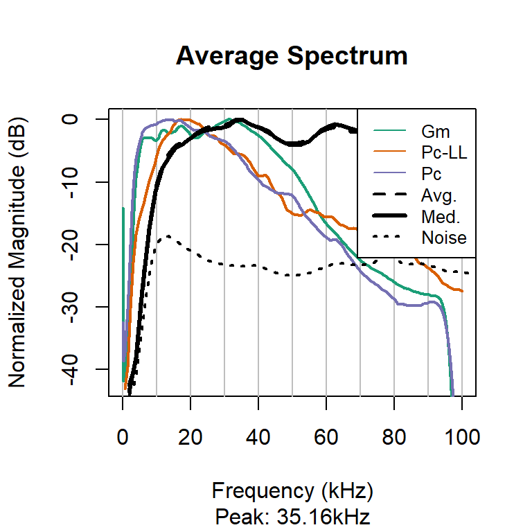

Median statistics for 3854 high SNR clicks with SNR >= 15 dB.

| parameter | value |
| --- | --- |
| Median Peak Frequency [kHz] | 31.2 |
| Median 3dB Center Frequency [kHz] | 31.2 |
| Median 10dB Center Frequency [kHz] | 32.1 |
| Median 3dB Bandwidth [kHz] (lower-upper) | 2.63 (29.5 - 33.7) |
| Median 10dB Bandwidth [kHz] (lower-upper) | 9.72 (25.6 - 38.4) |
| Median duration [μs] (25-75 percentile) | 142 (100 - 296) |

##### Whistle plots and table

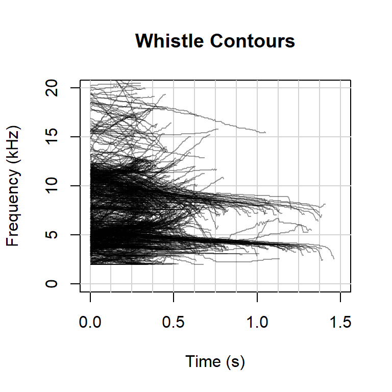

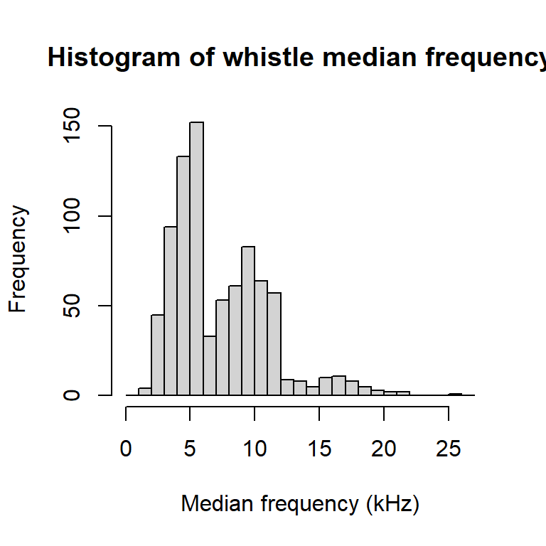

Median statistics for n = 843 whistles.

| parameter | value |
| --- | --- |
| Median begin frequency [kHz] | 5.93 |
| Median end frequency [kHz] | 6.88 |
| Median mean frequency [kHz] (SD) | 6.02 (0.42) |
| Median duration [s] | 0.389 |
| Median frequency range [kHz] (min-max) | 1.68 (4.98 - 7.69) |

#### Event ID: 1705119 | Species: 36

Time: 2017-09-14 03:49UTC to 2017-09-14 04:30UTC

Event contains 33298 original clicks, **1223 valid clicks** after filtering.

Event contains **631 whistles**.

##### Click plots and table

SNR histogram includes all filtered clicks. Other plots contain only clicks with SNR >= 15 dB (**n = 1162 clicks**) .

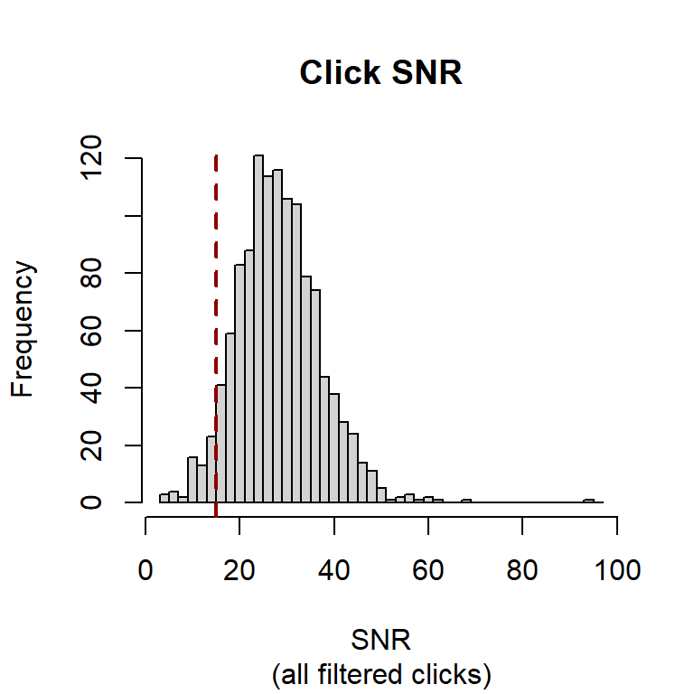

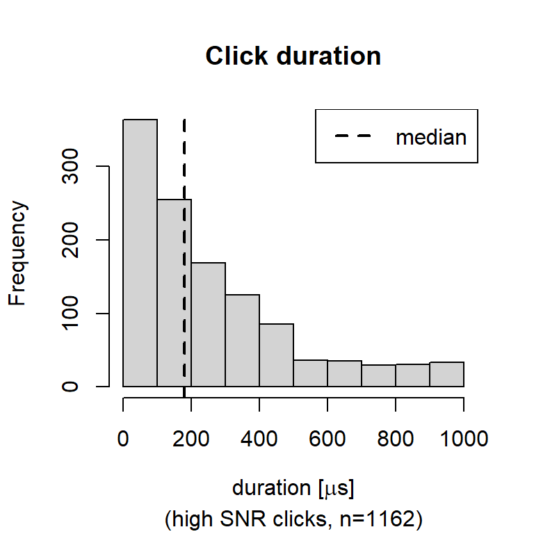

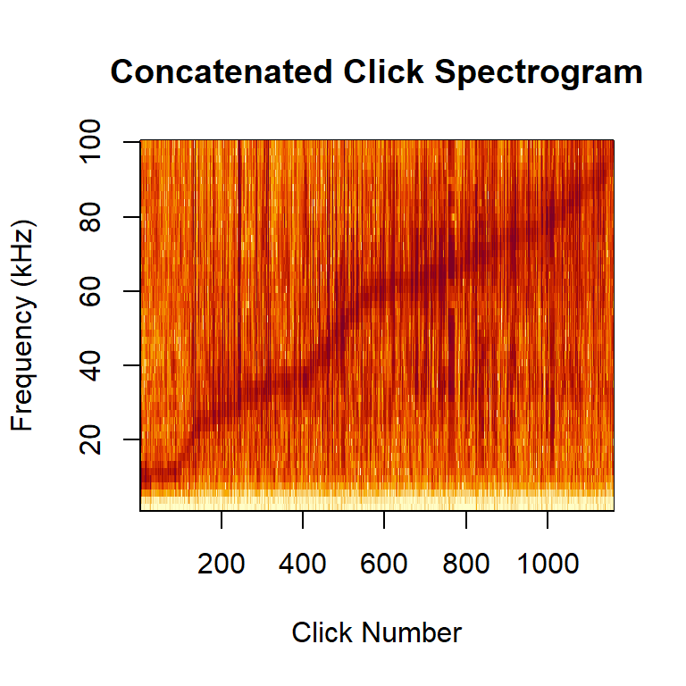

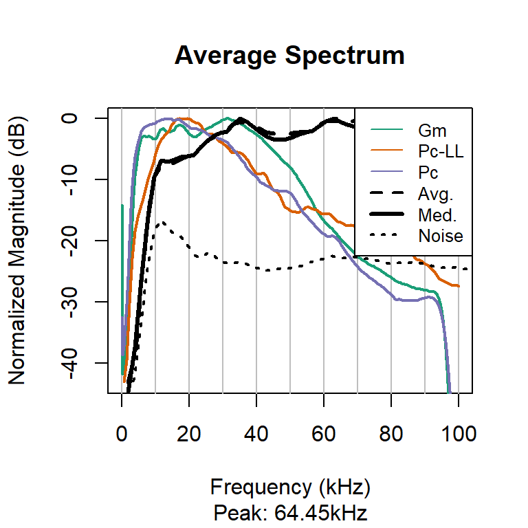

Median statistics for 1162 high SNR clicks with SNR >= 15 dB.

| parameter | value |
| --- | --- |
| Median Peak Frequency [kHz] | 34.4 |
| Median 3dB Center Frequency [kHz] | 34.4 |
| Median 10dB Center Frequency [kHz] | 34.2 |
| Median 3dB Bandwidth [kHz] (lower-upper) | 2.22 (32.6 - 36.2) |
| Median 10dB Bandwidth [kHz] (lower-upper) | 8.33 (28.2 - 40.4) |
| Median duration [μs] (25-75 percentile) | 180 (100 - 354) |

##### Whistle plots and table

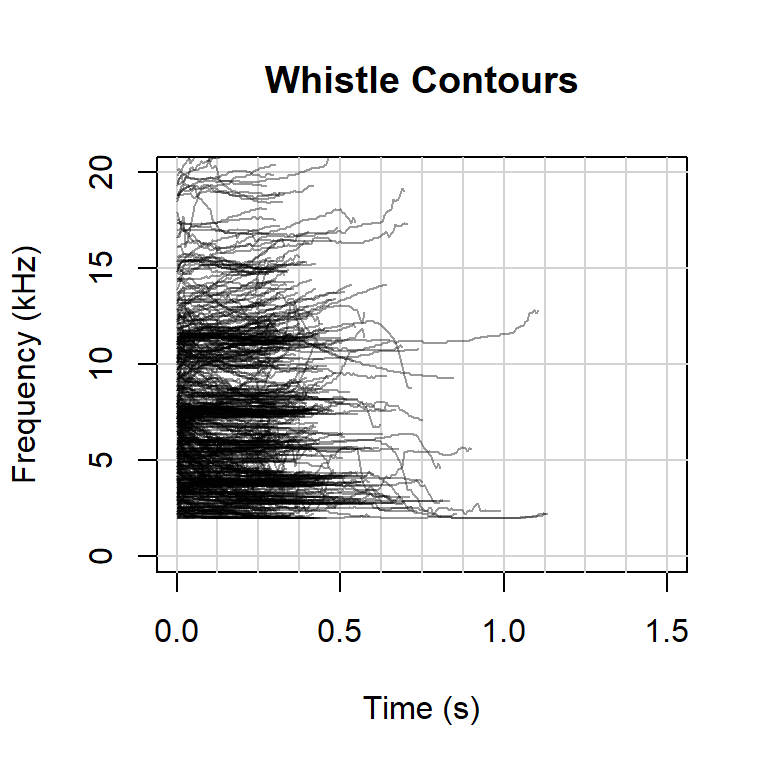

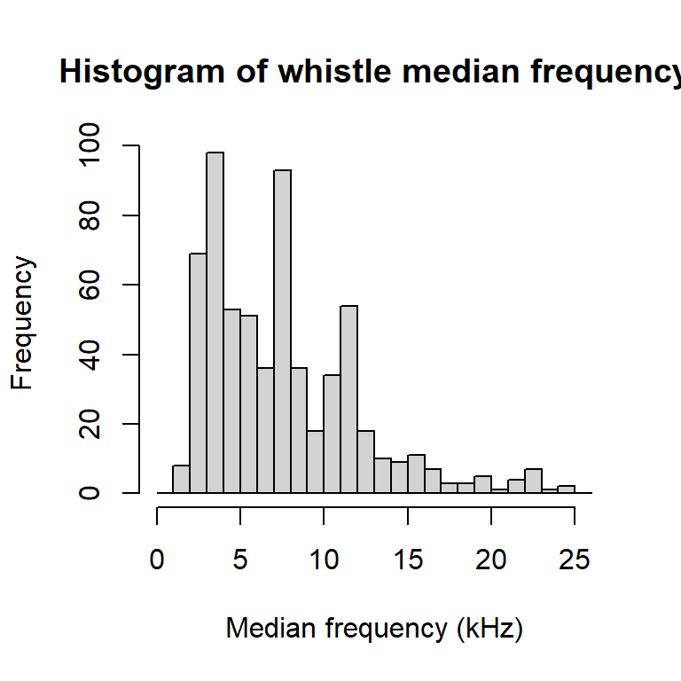

Median statistics for n = 631 whistles.

| parameter | value |
| --- | --- |
| Median begin frequency [kHz] | 7.03 |
| Median end frequency [kHz] | 6.96 |
| Median mean frequency [kHz] (SD) | 7.01 (0.23) |
| Median duration [s] | 0.355 |
| Median frequency range [kHz] (min-max) | 0.88 (6.37 - 7.47) |

#### Event ID: 1705324 | Species: 36

Time: 2017-11-16 17:39UTC to 2017-11-16 19:14UTC

Event contains 36301 original clicks, **1240 valid clicks** after filtering.

Event contains **95 whistles**.

##### Click plots and table

SNR histogram includes all filtered clicks. Other plots contain only clicks with SNR >= 15 dB (**n = 1082 clicks**) .

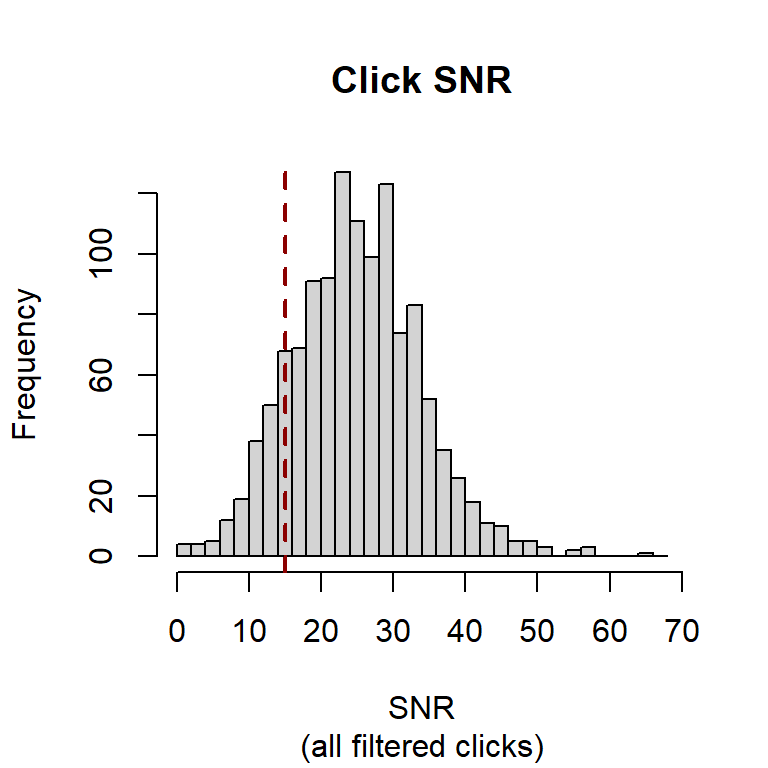

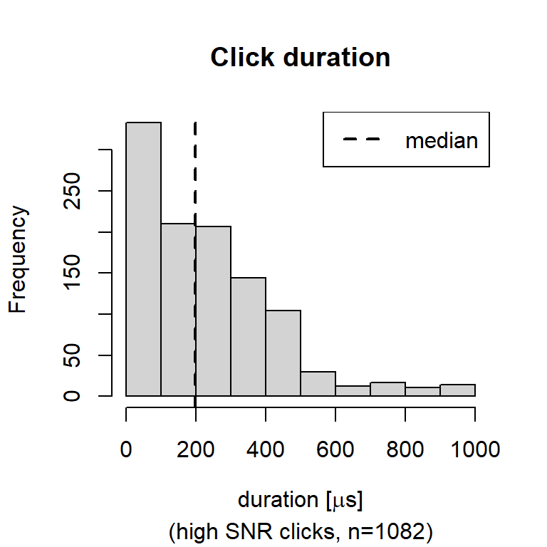

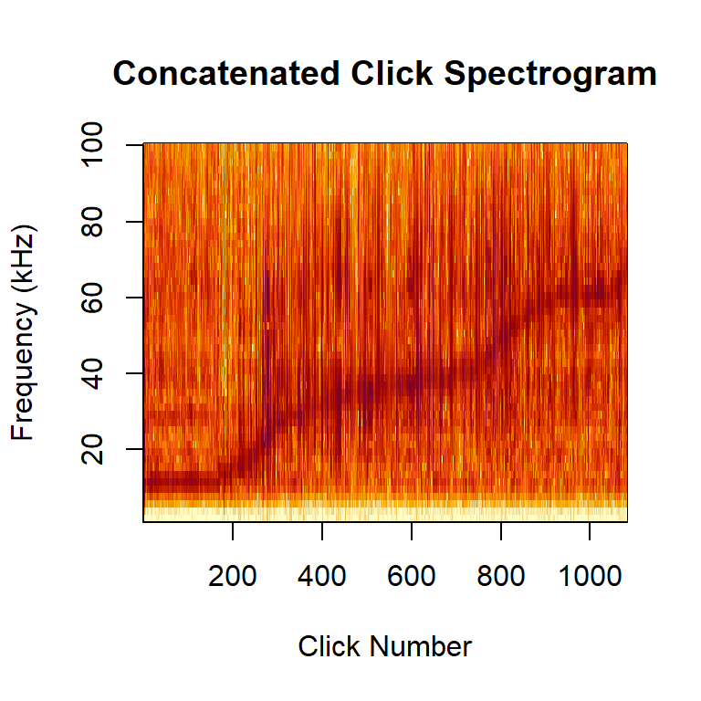

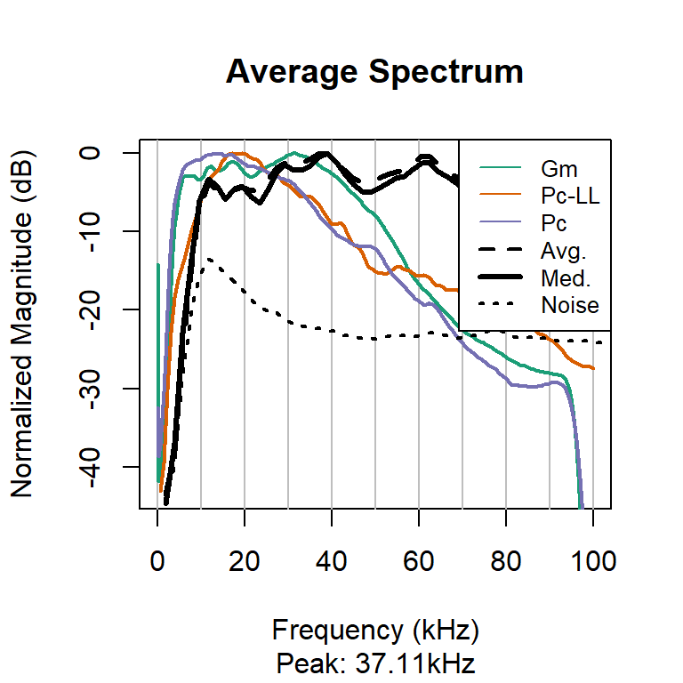

Median statistics for 1082 high SNR clicks with SNR >= 15 dB.

| parameter | value |
| --- | --- |
| Median Peak Frequency [kHz] | 26.6 |
| Median 3dB Center Frequency [kHz] | 26.9 |
| Median 10dB Center Frequency [kHz] | 27.9 |
| Median 3dB Bandwidth [kHz] (lower-upper) | 1.76 (25.7 - 28) |
| Median 10dB Bandwidth [kHz] (lower-upper) | 7.28 (21.8 - 33.4) |
| Median duration [μs] (25-75 percentile) | 198 (100 - 334) |

##### Whistle plots and table

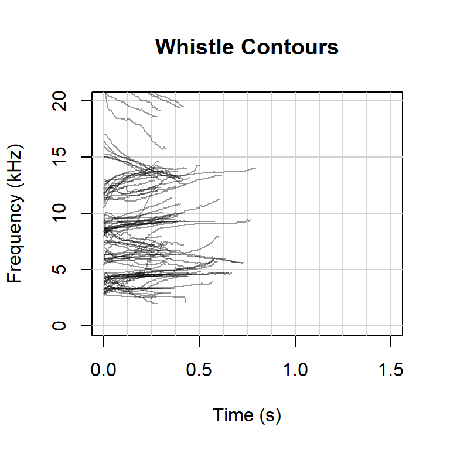

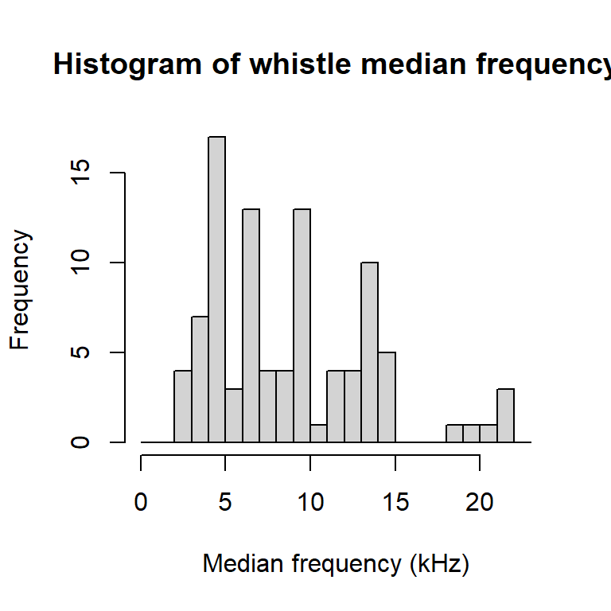

Median statistics for n = 95 whistles.

| parameter | value |
| --- | --- |
| Median begin frequency [kHz] | 8.06 |
| Median end frequency [kHz] | 7.98 |
| Median mean frequency [kHz] (SD) | 8.09 (0.40) |
| Median duration [s] | 0.362 |
| Median frequency range [kHz] (min-max) | 1.46 (7.10 - 9.08) |